# Data Science Capstone /Milestone Report Rubric

pierre arison

==================================================================

## Subject background

Text mining is an emerging technology that can be used to augment existing data in corporate databases by making unstructured text data available for analysis. The goal of this project is just to display that you’ve gotten used to working with the data and that you are on track to create your prediction algorithm.This include Data acquisition and cleaning, exploratory data analysis: At the end of this, make sure you have by applying the R text mining functions:

- Demonstrate that you’ve downloaded the data and have successfully loaded it in
- Create a basic report of summary statistics about the data sets.
- Report any interesting findings that you amassed so far.
- Get feedback on your plans for creating a prediction algorithm and Shiny app.

# Data source

The data for this project is from a corpus called HC Corpora available on: http://:www.corpora.heliohost.org with his readme file at http://www.corpora.heliohost.org/aboutcorpus.html. The training Dataset can be download from the Coursera site and not from external websites by clicking [Capstone Dataset](https://d396qusza40orc.cloudfront.net/dsscapstone/dataset/Coursera-SwiftKey.zip)

# data processing

- Working directory

```r
setwd("C:/Users/ryUser/Documents/capstone/DS_capstone/Coursera-SwiftKey/final/en_US")
```

- data use in this part of project

We use three texts files en_US.news.txt, en_US.blogs.txt, en_US.twitter.txt in this part of project with is in US english.

- Loading Texts Dataset and Extracts specific files from a zip file

```r
destfile <- "Coursera-SwiftKey.zip"
sourcefile<- "http://d396qusza40orc.cloudfront.net/dsscapstone/dataset/Coursera-SwiftKey.zip"
download.file(sourcefile, destfile)
#unzip(destfile)
unzip(destfile, list = TRUE )
```

```
##                             Name    Length                Date
## 1                         final/         0 2014-07-22 10:10:00
## 2                   final/de_DE/         0 2014-07-22 10:10:00
## 3  final/de_DE/de_DE.twitter.txt  75578341 2014-07-22 10:11:00
## 4    final/de_DE/de_DE.blogs.txt  85459666 2014-07-22 10:11:00
## 5     final/de_DE/de_DE.news.txt  95591959 2014-07-22 10:11:00
## 6                   final/ru_RU/         0 2014-07-22 10:10:00
## 7    final/ru_RU/ru_RU.blogs.txt 116855835 2014-07-22 10:12:00
## 8     final/ru_RU/ru_RU.news.txt 118996424 2014-07-22 10:12:00
## 9  final/ru_RU/ru_RU.twitter.txt 105182346 2014-07-22 10:12:00
## 10                  final/en_US/         0 2014-07-22 10:10:00
## 11 final/en_US/en_US.twitter.txt 167105338 2014-07-22 10:12:00
## 12    final/en_US/en_US.news.txt 205811889 2014-07-22 10:13:00
## 13   final/en_US/en_US.blogs.txt 210160014 2014-07-22 10:13:00
## 14                  final/fi_FI/         0 2014-07-22 10:10:00
## 15    final/fi_FI/fi_FI.news.txt  94234350 2014-07-22 10:11:00
## 16   final/fi_FI/fi_FI.blogs.txt 108503595 2014-07-22 10:12:00
## 17 final/fi_FI/fi_FI.twitter.txt  25331142 2014-07-22 10:10:00
```

==================================================================

*Load the R package for text mining and then load your texts into R*

We have to use the the tm key package that makes analysis of unstructured data available to the R users, package stringr for convenient way to override the current encoding of a string stringi for Character String Processing Facilities stringdist for approximate string matching Rweka usefull for the tokenization steps

```r
options(warn=-1)
library(stringr)
library(stringi)
library(stringdist)
library(tm)
library(RWeka)
```

*Basic Statistics and files Informations*

```r
library(knitr)
twitter <- system('wc -lwm C:/Users/ryUser/Documents/capstone/DS_capstone/Coursera-SwiftKey/final/en_US/en_US.twitter.txt',intern = T)
news <- system('wc -lwm C:/Users/ryUser/Documents/capstone/DS_capstone/Coursera-SwiftKey/final/en_US/en_US.news.txt',intern = T)
blogs <- system('wc -lwm C:/Users/ryUser/Documents/capstone/DS_capstone/Coursera-SwiftKey/final/en_US/en_US.blogs.txt',intern = T)
TWITTERS.NUM <- as.numeric(grep('[[:digit:]]', unlist(strsplit(twitter," ")), value = T))
NEWS.NUM<- as.numeric(grep('[[:digit:]]', unlist(strsplit(news," ")), value = T))
BLOGS.NUM<- as.numeric(grep('[[:digit:]]', unlist(strsplit(blogs," ")), value = T))
Combine_US <- as.data.frame(rbind(TWITTERS.NUM,NEWS.NUM,BLOGS.NUM))
rownames(Combine_US) <- c('twitter','news','blogs')
colnames(Combine_US) <- c('line counts','word counts','document size')
kable(Combine_US, align='c', caption = "Summary of the datasets")
```

Summary of the datasets

|  | line counts | word counts | document size |
| --- | --- | --- | --- |
| twitter | 2360148 | 30341028 | 167105338 |
| news | 1010242 | 34309642 | 205811889 |
| blogs | 899288 | 37272578 | 210160014 |

- Reading data into R environment

```r
options(warn=-1)
setwd("C:/Users/ryUser/Documents/capstone/DS_capstone/Coursera-SwiftKey/final/en_US")
TWITTERS <- readLines("en_US.twitter.txt", encoding="UTF-8")
BLOGS <- readLines("en_US.blogs.txt", encoding="UTF-8")
NEWS <- readLines("en_US.news.txt", encoding="UTF-8")
```

```r
stri_stats_general(NEWS)
```

```
##       Lines LinesNEmpty       Chars CharsNWhite
##       77259       77259    15639408    13072698
```

```r
stri_stats_general(TWITTERS)
```

```
##       Lines LinesNEmpty       Chars CharsNWhite
##     2360148     2360148   162096031   134082634
```

```r
stri_stats_general(BLOGS)
```

```
##       Lines LinesNEmpty       Chars CharsNWhite
##      899288      899288   206824382   170389539
```

```r
combine1 <- append(TWITTERS, BLOGS)
combine_US<- append(combine1, NEWS)
set.seed(123)
samplecombine_US <- sample(combine_US, length(combine_US) * 0.01)
writeLines(samplecombine_US,"C:/Users/ryUser/Documents/capstone/DS_capstone/Coursera-SwiftKey/milstoneDATA/samplecombine_US.txt")
```

- Defining a corpus of texts data using the sample of combine file of three files

A corpus, in natural language processing, is a body or collection of text information. In order to apply many of the capabilities of R, it is necessary to convert the file that was read into the format that the tm packages function requires. To do this the file must be converted to a corpus.

```r
cname <- file.path("C:/Users/ryUser/Documents/capstone/DS_capstone/Coursera-SwiftKey/", "milstoneDATA")
corpus <- Corpus(DirSource(cname))
```

*Preparing the Corpus*

We perform some pre-processing of the text data to prepare for the text analysis. Example transformations include converting the text to lower case, removing numbers and punctuation, removing stopwords, stemming and identifying synonyms.

```r
toSpace <- content_transformer(function(x, pattern) gsub(pattern, " ", x))
corpus <- tm_map(corpus, toSpace, "a-z A-Z 0-9!/|@|- <>\\|'+")
#corpus <- tm_map(corpus, toSpace, "[^ a-z A-Z 0-9!',\\-./:;<?@()]+|\"'")
```

```r
library(SnowballC)
corpus <- tm_map(corpus, stripWhitespace)
corpus <- tm_map(corpus, content_transformer(tolower))
corpus <- tm_map(corpus, stemDocument)
corpus<- tm_map(corpus,removePunctuation)
corpus<- tm_map(corpus,removeNumbers)
corpus<- tm_map(corpus, removeWords, stopwords("english"))
corpus<- tm_map(corpus, removeWords, "<U+0096>")
corpus <- tm_map(corpus, PlainTextDocument)
```

- Creating a Do cument Term Matrix

```r
#dtm <- DocumentTermMatrix(corpus)
#dtm
```

*Tokenization*

Tokenization is the process of breaking a stream of text up into phrases, words, symbols, or other meaningful elements called tokens. The goal of the tokenization is the exploration of the words in a sentence.We also have to tokenize our corpus.

```r
library(RWeka)
Tokenizer <- function(x) NGramTokenizer(x, Weka_control(min = 1, max = 1))
unidtm <- DocumentTermMatrix(corpus,control = list(tokenize = Tokenizer))

BigramTokenizer <- function(x) NGramTokenizer(x, Weka_control(min = 2, max = 2))
bidtm <- DocumentTermMatrix(corpus,control = list(tokenize = BigramTokenizer))

TrigramTokenizer <- function(x) NGramTokenizer(x, Weka_control(min = 3, max = 3))
tridtm <- DocumentTermMatrix(corpus,control = list(tokenize = TrigramTokenizer))

fourgramTokenizer <- function(x) NGramTokenizer(x, Weka_control(min = 4, max = 4))
fourdtm <- DocumentTermMatrix(corpus,control = list(tokenize = fourgramTokenizer))
```

# Distribution of Term Frequencies

- Definition*
- a unigram is a sequence of one word
- a bigram is a sequence of two words
- a trigram is a sequence of three words  
  and so on and so force the general term n-gram means ‘sequence of length n’

The specificity of various words is a useful property for making distinctions between different documents in a corpus, Relating Word Frequencies to Known Dimensions of Interest. The results below show that: The most frequent word of unigrams is: *just* and the for bigrams we have: *right now*,for trigrams we have: *hi hi hi* and for fourgrams we have: *hi hi hi hi*, in the sample corpus

- The five highest frequencies of Unigrams

```r
tm_unifreq <- sort(colSums(as.matrix(unidtm)), decreasing=TRUE)
tm_uniwordfreq <- data.frame(word=names(tm_unifreq), freq=tm_unifreq)
head(tm_uniwordfreq,5)
```

```
##      word freq
## just just 2593
## get   get 2473
## like like 2442
## will will 2185
## one   one 2162
```

- The five highest frequencies of bigrams

```r
tm_bifreq <- sort(colSums(as.matrix(bidtm)), decreasing=TRUE)
tm_biwordfreq <- data.frame(word=names(tm_bifreq), freq=tm_bifreq)
head(tm_biwordfreq ,5)
```

```
##                      word freq
## right now       right now  225
## look like       look like  175
## look forward look forward  174
## cant wait       cant wait  171
## feel like       feel like  167
```

- The five highest frequencies of Trigrams

```r
tm_trifreq <- sort(colSums(as.matrix(tridtm)), decreasing=TRUE)
tm_triwordfreq <- data.frame(word=names(tm_trifreq), freq=tm_trifreq)
head(tm_triwordfreq ,5)
```

```
##                              word freq
## hi hi hi                 hi hi hi   45
## cant wait see       cant wait see   34
## happi mother day happi mother day   32
## let us know           let us know   28
## happi new year     happi new year   24
```

- The five highest frequencies of fourgrams

```r
tm_fourfreq <- sort(colSums(as.matrix(fourdtm)), decreasing=TRUE)
tm_fourwordfreq <- data.frame(word=names(tm_fourfreq), freq=tm_fourfreq)
head(tm_fourwordfreq ,5)
```

```
##                                            word freq
## hi hi hi hi                         hi hi hi hi   44
## brew system silver        brew system silver     8
## cuisinart ss singl serv cuisinart ss singl serv    8
## serv brew system silver serv brew system silver    8
## silver  power keurig     silver  power keurig    8
```

==================================================================

# Plotting Word Frequencies

- Unigrams

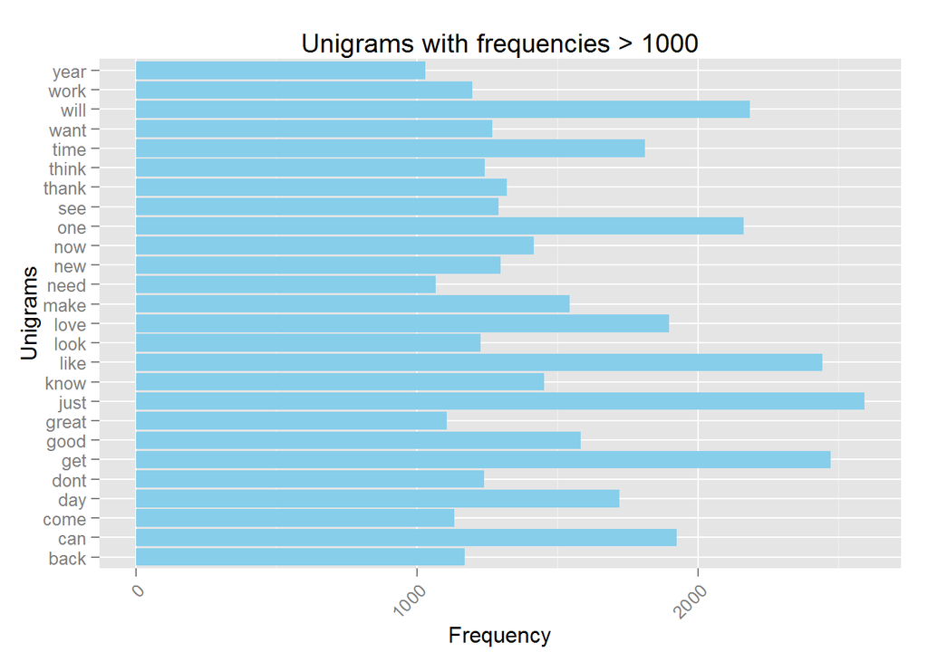

```r
library(ggplot2)
library(dplyr)
tm_uniwordfreq %>%
  filter(freq > 1000) %>%
  ggplot(aes(word,freq)) +
  geom_bar(stat="identity",fill = "Sky Blue") +
  ggtitle("Unigrams with frequencies > 1000") +
  xlab("Unigrams") + ylab("Frequency") +
  theme(axis.text.x=element_text(angle=45, hjust=1))+ coord_flip()
```

- Bigrams

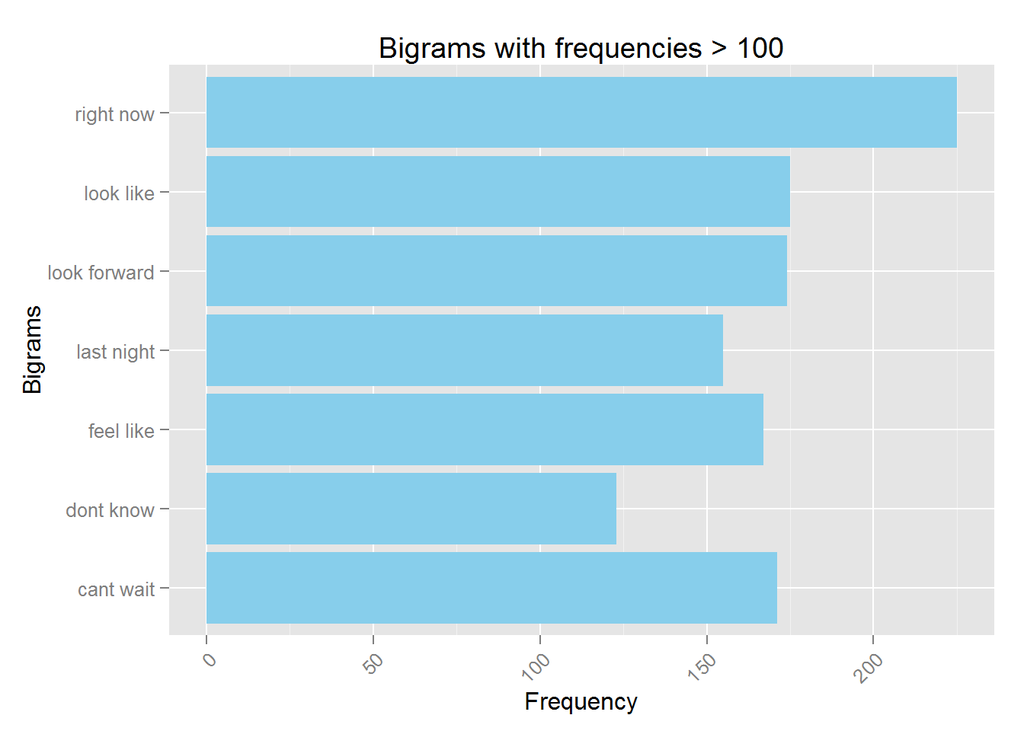

```r
tm_biwordfreq %>%
  filter(freq > 100) %>%
  ggplot(aes(word,freq)) +
  geom_bar(stat="identity",fill = "Sky Blue") +
  ggtitle("Bigrams with frequencies > 100") +
  xlab("Bigrams") + ylab("Frequency") +
  theme(axis.text.x=element_text(angle=45, hjust=1))+ coord_flip()
```

- Trigrams

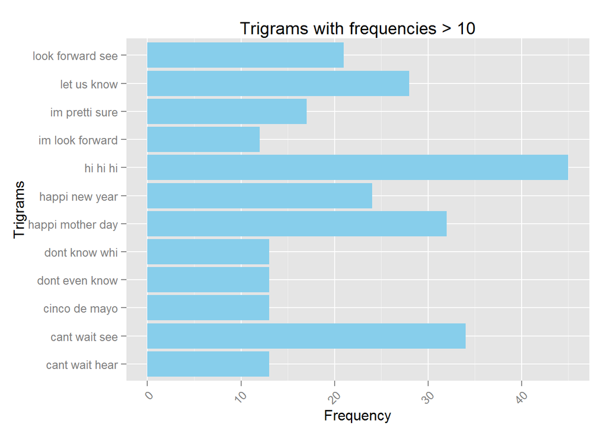

```r
tm_triwordfreq %>%
  filter(freq > 10) %>%
  ggplot(aes(word,freq)) +
  geom_bar(stat="identity",fill = "Sky Blue") +
  ggtitle("Trigrams with frequencies > 10") +
  xlab("Trigrams") + ylab("Frequency") +
  theme(axis.text.x=element_text(angle=45, hjust=1))+ coord_flip()
```

- Fourgrams

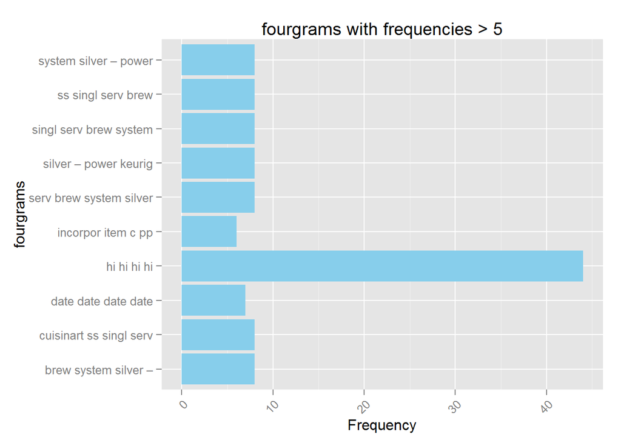

```r
tm_fourwordfreq %>%
  filter(freq > 5) %>%
  ggplot(aes(word,freq)) +
  geom_bar(stat="identity",fill = "Sky Blue") +
  ggtitle("fourgrams with frequencies > 5") +
  xlab("fourgrams") + ylab("Frequency") +
  theme(axis.text.x=element_text(angle=45, hjust=1))+ coord_flip()
```

==================================================================

# Word Clouds

The most frequent terms appear in the center of the cloud and are larger. The colors that the terms are printed in also changes as the frequency decreases.

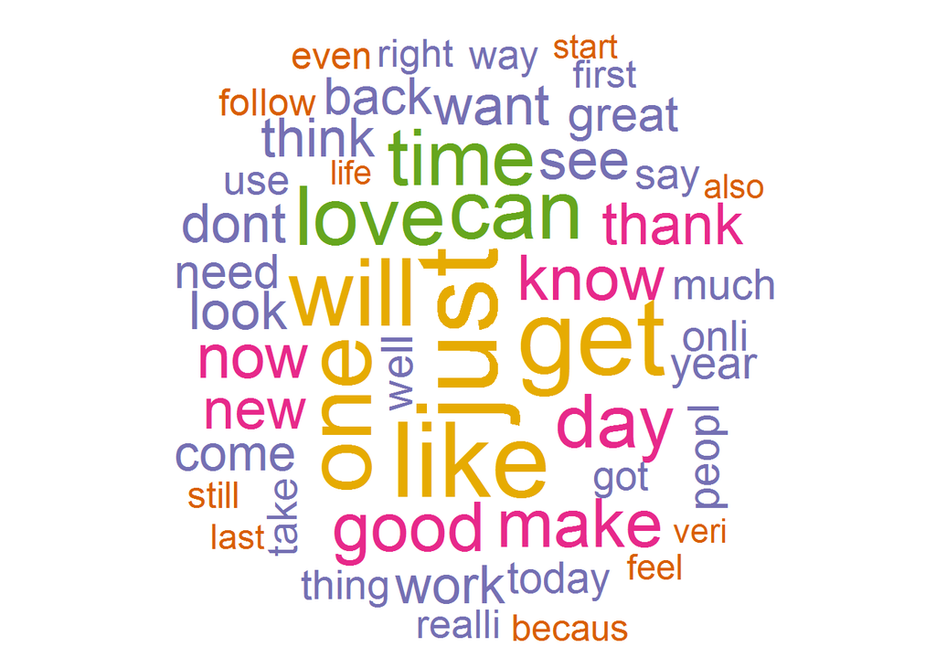

```r
options(warn=-1)
library(wordcloud)
set.seed(39)
wordcloud(names(tm_unifreq), tm_unifreq, max.words=50,scale=c(5,.1),random.order=FALSE, colors=brewer.pal(6, "Dark2"))
```

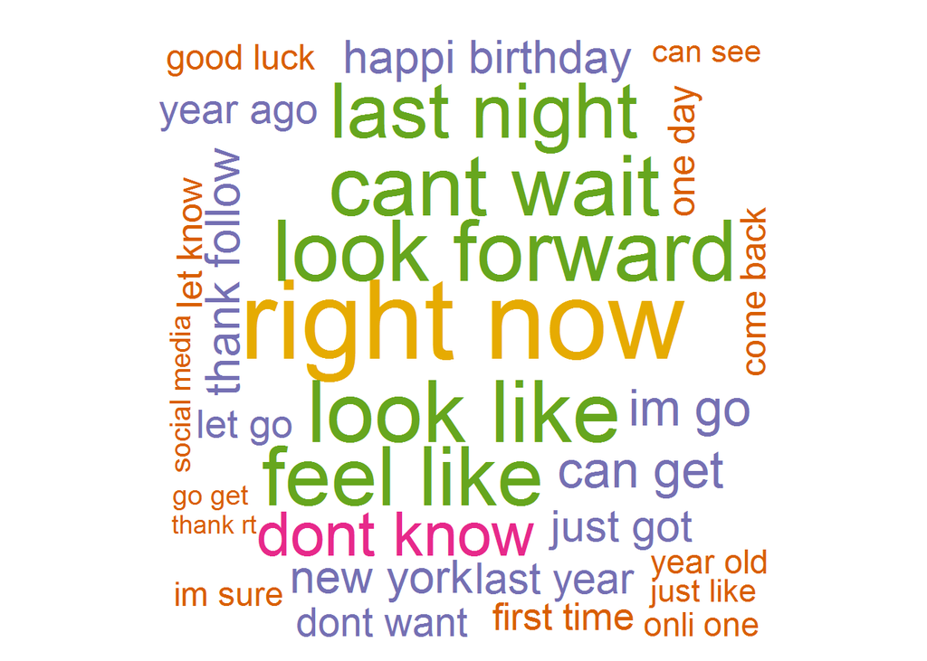

```r
wordcloud(names(tm_bifreq), tm_bifreq, max.words=50, scale=c(5, .1),random.order=FALSE, colors=brewer.pal(6, "Dark2"))
```

[figure not shown]

```r
wordcloud(names(tm_trifreq), tm_trifreq, max.words=25, scale=c(5, .1),random.order=FALSE, colors=brewer.pal(6, "Dark2"))
```

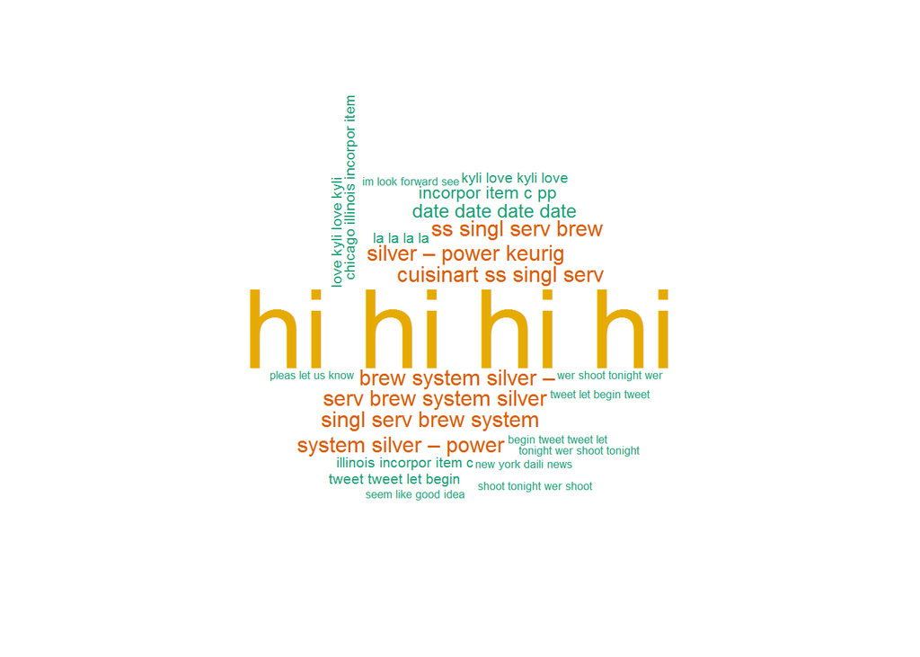

```r
wordcloud(names(tm_fourfreq), tm_fourfreq, max.words=25, scale=c(5, .1),random.order=FALSE, colors=brewer.pal(6, "Dark2"))
```

==================================================================

# Next steps

- The next step of this project is base on corpus counts for building the next word prediction model.Here I will Develop more n-grams.The method I will used is the Maximum Likelihood Estimation (MLE)
- Building the Shiny app to demonstrate the model.